# GIUDITTA - Bayerische Staatsoper

[figure not shown]

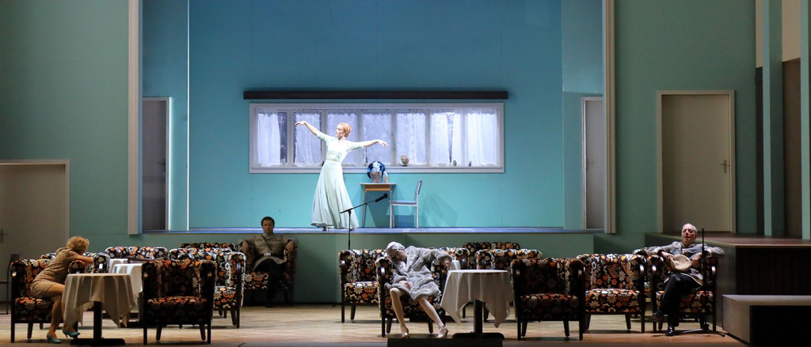

# GIUDITTA

empfohlen ab 15 Jahren  
Spieloper in fünf Bildern von Franz Lehár (1932/33)  
In einer Fassung von Christoph Marthaler und Malte Ubenauf  
Unter Verwendung von Liedern und Orchesterkompositionen von Lehárs Zeitgenossen B. Bartók, A. Berg, H. Eisler, E. W. Korngold, E. Krenek, A. Schönberg, D. Schostakowitsch, I. Strawinsky, V. Ullmann sowie Dialogen aus Ö. v. Horváths „Sladek oder Die schwarze Armee“ (1928).

Komponist Franz Lehár. Buch von Paul Knepler und Fritz Löhner-Beda.  
In deutscher Sprache · Mit Übertiteln in deutscher und englischer Sprache. Neuproduktion.

Premiere am 18. Dezember 2021

Samstag, 18. Dezember 2021, 18.00 Uhr – 21.00 Uhr, Nationaltheater.

**Dauer** ca. 3 Stunden

**1. - 3. Bild** (ca. 18.00 - 19.30 Uhr) Pause (ca. 19.30 - 20.00 Uhr) **4. und 5. Bild** (ca. 20.00 - 21.00 Uhr)

PREMIERE!  
Abo-Serie 44, Giuditta

[Termin merken](https://www.staatsoper.de/stuecke/giuditta/2021-12-18-1800-12713/calendar.ics)

*Giuditta* sollte Franz Lehárs Eintrittskarte in die Welt der Oper sein: Uraufgeführt wurde seine „Spieloper“ oder auch „Musikalische Komödie“ im Januar 1934. Lehárs musikalisch opulent inszenierte, letzte Operette *Giuditta* wurde enthusiastisch gefeiert. 120 Rundfunkstationen waren laut zeitgenössischer Quellen an der weltweiten Übertragung 1934 beteiligt. Erstaunlich zwitterhaft ist *Giudittas* musikalische Gestalt: Rauschhafte Melodien und Anleihen an den von Lehár verehrten Puccini und dessen tragisch liebende Figuren stehen neben operettenhafter Unverfänglichkeit. Heute kennt man nur die berühmten Schlager *Meine Lippen, sie küssen so heiß* und *Freunde, das Leben ist lebenswert*. Doch das Ende der Handlung ist keineswegs heiter, das Liebespaar Giuditta und Octavio gehen resigniert getrennte Wege, Hauptmann Octavio bleibt als gescheiterter Mann einsam zurück. Die „musikalische Komödie“ steht so nur scheinbar im krassen Kontrast zur gesellschaftlichen Gegenwart des aufkommenden Krieges, den 1930er Jahren.

Der für seine launisch-schönen Theaterabende bekannte Regisseur Christoph Marthaler greift die Ambivalenz der Figuren von Lehár auf, die zwischen Opulenz und Resignation, zwischen Euphorie und Abgrund schwanken. Orchestermusiken von Béla Bartók, Erich Korngold oder Dmitri Schostakowitsch, Lieder von Viktor Ullmann, Hanns Eisler oder Alban Berg sowie Auszüge aus *Sladek oder Die Schwarze Armee* von Ödön von Horváth stellen Lehárs Operette radikal in den Kontext seiner Entstehungszeit. *Giuditta* in der Fassung von Christoph Marthaler erzählt eine Liebesgeschichte innerhalb der Wirrungen und Irrungen der Zeit.

IN DER REIHENFOLGE IHRER VERWENDUNG IN DER FASSUNG DER BAYERISCHEN STAATSOPER

DIE HEIMAT (1940)  
aus *Hollywood Liederbuch*  
Musik: Hanns Eisler  
Text: nach Friedrich Hölderlin

FIEBER (Auszug) (1915)  
Nr. 5 aus der Tondichtung *Aus eiserner Zeit* für Stimme und Orchester  
Musik: Franz Lehár  
Text: Erwin Weill

WO HAST DU ALL DIE SCHÖNHEIT HERGENOMMEN (1939)  
aus den *Fünf Liebesliedern* nach Texten von Ricarda Huch  
Musik: Viktor Ullmann  
Text: Ricarda Huch

GEWITTERREGEN (1912)  
aus den Fünf Orchesterliedern nach Texten von Peter Altenberg  
Musik: Alban Berg  
Text: Peter Altenberg

Béla Bartók  
DER WUNDERBARE MANDARIN für Orchester (Ausschnitt), Konzertfassung (1928)

JA! O JA! (1910-1913)  
aus *Die Glückliche Hand* op. 18  
Musik und Text: Arnold Schönberg

HIER IST FRIEDEN (1912)  
aus den Fünf Orchesterliedern nach Texten von Peter Altenberg  
Musik: Alban Berg  
Text: Peter Altenberg

DU KANNST DICH ZURÜCKHALTEN VON DEN LEIDEN DER WELT (1937 / 38)  
aus 5 Lieder nach Worten von Franz Kafka op. 82 Nr. 4  
Musik: Ernst Krenek  
Text: Franz Kafka

Igor Strawinsky  
WALTZ-CODA aus JEU DE CARTES, Ballett in drei „Runden“ (1936)

Dmitri D. Schostakowitsch  
TANGO. KOSOLKOVS TANZ MIT FREUNDEN aus dem Ballet THE BOLT op. 27 für Orchester (1931)

GLÜCK, DAS MIR VERBLIEB (1912)  
aus *Die tote Stadt* op. 12  
Musik: Erich W. Korngold  
Text: Paul Schott

ÜBER DEN SELBSTMORD (1939)  
aus *Hollywood Liederbuch*  
Musik: Hanns Eisler  
Text: Bertold Brecht

COME AWAY, DEATH (1937)  
aus *Songs of the Clown* op. 29  
Musik: Erich W. Korngold  
Text: William Shakespeare

Gideon Klein  
STREICHTRIO Es-Dur, 2. Satz Lento (Anfang) (1943)

Dmitri D. Schostakowitsch  
III. FRAGMENT (LARGO) aus FÜNF FRAGMENTE FÜR ORCHESTER op. 42 (1935)

[Download Besetzungszettel (PDF)](https://www.staatsoper.de/media/content/PDF/Besetzungszettel_21_22/Giuditta_21_12_18__I.pdf)

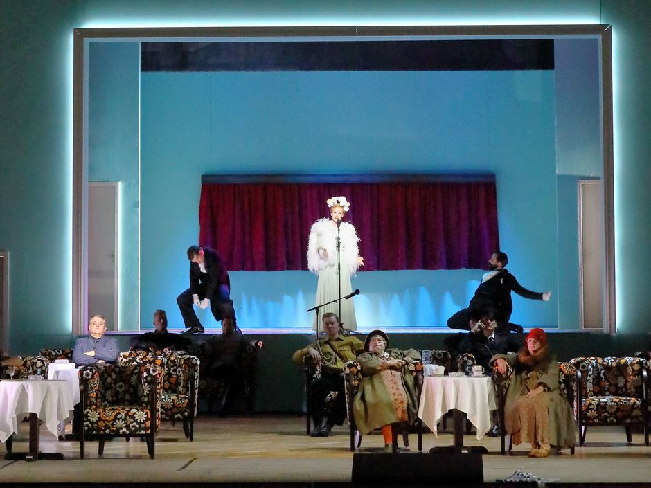

GIUDITTA © Wilfried Hösl

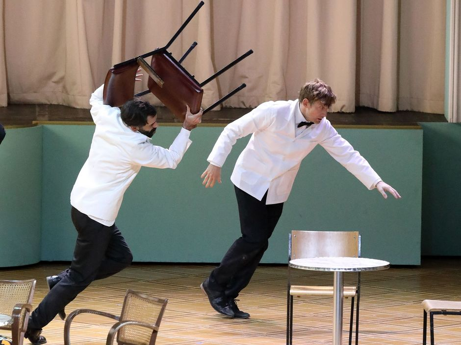

GIUDITTA - J.P. Abella, S. Zuber © Wilfried Hösl

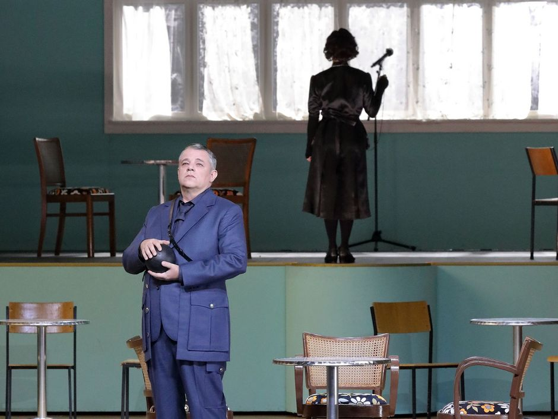

GIUDITTA - J. Schmeckenbecher © Wilfried Hösl

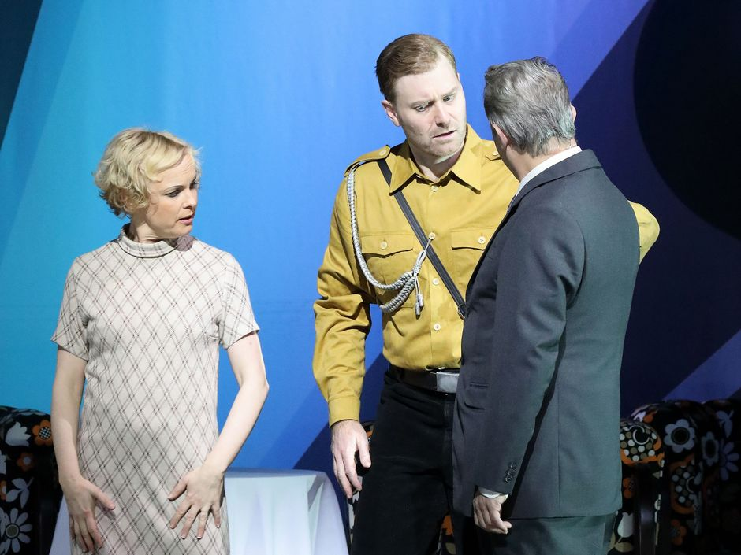

GIUDITTA - K. Avemo, S. Kohlhepp, M. Bodnarc © Wilfried Hösl

## weitere Vorstellungen

So 12.02.23

## GIUDITTA

Franz Lehár  
18.00 Uhr, Nationaltheater  
Abo-Opern-Geschenk-Abo 171, <30

Preise K , € 132 / 115 / 95 / 74 / 52 / 30 / 14 / 10

Oper

[Tickets](https://www.staatsoper.de/kartenanfrage?tx_sfstaatsoper_cardorderlist%5Bactivity%5D=13299&tx_sfstaatsoper_cardorderlist%5Bcontroller%5D=CardOrder&cHash=fa83ab60f2b7fe7e33ed8a2d3c344306)

[VVK-Termin merken](https://www.staatsoper.de/stuecke/giuditta/2023-02-12-1800-13299/calendar.ics)

Mi 15.02.23

## GIUDITTA

Franz Lehár  
19.00 Uhr, Nationaltheater  
Abo-Serie 32

Preise K , € 132 / 115 / 95 / 74 / 52 / 30 / 14 / 10

Oper

[Tickets](https://www.staatsoper.de/kartenanfrage?tx_sfstaatsoper_cardorderlist%5Bactivity%5D=13302&tx_sfstaatsoper_cardorderlist%5Bcontroller%5D=CardOrder&cHash=0619fb511ae2c2157aa377659d8ee726)

[VVK-Termin merken](https://www.staatsoper.de/stuecke/giuditta/2023-02-15-1900-13302/calendar.ics)

Sa 18.02.23

## GIUDITTA

Franz Lehár  
19.00 Uhr, Nationaltheater  
Abo-Serie 61

Preise K , € 132 / 115 / 95 / 74 / 52 / 30 / 14 / 10

Oper

[Tickets](https://www.staatsoper.de/kartenanfrage?tx_sfstaatsoper_cardorderlist%5Bactivity%5D=13304&tx_sfstaatsoper_cardorderlist%5Bcontroller%5D=CardOrder&cHash=393119911d3569f022da3fbdc717f6e9)

[VVK-Termin merken](https://www.staatsoper.de/stuecke/giuditta/2023-02-18-1900-13304/calendar.ics)

Di 21.02.23

## GIUDITTA

Franz Lehár  
19.00 Uhr, Nationaltheater  
Abo-Serie 51

Preise K , € 132 / 115 / 95 / 74 / 52 / 30 / 14 / 10

Oper

[Tickets](https://www.staatsoper.de/kartenanfrage?tx_sfstaatsoper_cardorderlist%5Bactivity%5D=13306&tx_sfstaatsoper_cardorderlist%5Bcontroller%5D=CardOrder&cHash=1f8d3f0cdd91512f5b4d8a71c1b3c586)

[VVK-Termin merken](https://www.staatsoper.de/stuecke/giuditta/2023-02-21-1900-13306/calendar.ics)

[video not shown]

## Vergangene Vorstellungen

Do 06.01.22

## GIUDITTA

Franz Lehár  
18.00 Uhr, Nationaltheater

Oper

So 02.01.22

## GIUDITTA

Franz Lehár  
18.00 Uhr, Nationaltheater

Oper

Fr 31.12.21

## GIUDITTA

Franz Lehár  
18.00 Uhr, Nationaltheater

Oper

Mo 27.12.21

## GIUDITTA

Franz Lehár  
19.00 Uhr, Nationaltheater

Oper

Mi 22.12.21

## GIUDITTA

Franz Lehár  
19.00 Uhr, Nationaltheater

Oper

Sa 18.12.21

## GIUDITTA

Franz Lehár  
18.00 Uhr, Nationaltheater

Oper

So 05.12.21

## GIUDITTA

Franz Lehár  
11.00 Uhr, Nationaltheater

Oper

## DIE VERKAUFTE BRAUT

Bedřich Smetana  
19.00 Uhr, Nationaltheater  
Abo-Serie 10

Preise K , € 132 /115 /95 /- /- /- /14 /10

Oper

[Tickets](https://tickets.staatstheater.bayern/bso.webshop/webticket/shop?language=de&event=34852)

[Termin merken](https://www.staatsoper.de/stuecke/die-verkaufte-braut/2023-01-02-1900-13263/calendar.ics)

Mi 04.01.23

## DIE FLEDERMAUS

Johann Strauß  
19.00 Uhr, Nationaltheater  
Abo-Serie 22

Preise K , € 132 /115 /- /- /- /- /14 /10

Oper

[Tickets](https://tickets.staatstheater.bayern/bso.webshop/webticket/shop?language=de&event=34844)

[Termin merken](https://www.staatsoper.de/stuecke/die-fledermaus/2023-01-04-1900-13264/calendar.ics)

Do 05.01.23

## Kindereinführung - DIE VERKAUFTE BRAUT

18.45 Uhr, Königssaal im Nationaltheater

Preise PG3 , € 3

KIND&CO

[Tickets](https://tickets.staatstheater.bayern/bso.webshop/webticket/shop?language=de&event=35260)

[Termin merken](https://www.staatsoper.de/stuecke/kindereinfuehrung/2023-01-05-1845-13535/calendar.ics)

Do 05.01.23

## DIE VERKAUFTE BRAUT

Bedřich Smetana  
19.30 Uhr, Nationaltheater  
Abo-Familien-Geschenk-Abo 179, <30, Familienvorstellung

Preise K , € 132 /115 /95 /74 /52 /- /14 /10

Oper

[Tickets](https://tickets.staatstheater.bayern/bso.webshop/webticket/shop?language=de&event=34853)

[Termin merken](https://www.staatsoper.de/stuecke/die-verkaufte-braut/2023-01-05-1930-13265/calendar.ics)

Fr 06.01.23

## Kindereinführung - DIE FLEDERMAUS

15.15 Uhr, Königssaal im Nationaltheater

Preise PG3

KIND&CO

Fr 06.01.23

## DIE FLEDERMAUS

Johann Strauß  
16.00 Uhr, Nationaltheater  
Familienvorstellung

Preise K , € 132 /115 /- /- /- /- /14 /10

Oper

[Tickets](https://tickets.staatstheater.bayern/bso.webshop/webticket/shop?language=de&event=34845)

[Termin merken](https://www.staatsoper.de/stuecke/die-fledermaus/2023-01-06-1600-13266/calendar.ics)

Fr 06.01.23

## Gastspielkonzert des Opernstudios

16.00 Uhr, Pollinger Bibliotheksaal

Konzert

[Tickets](https://muenchen.hoertnagel.de/hn/veranstaltungen/neujahrskonzert-6123)

Sa 07.01.23

## DIE VERKAUFTE BRAUT

Bedřich Smetana  
19.00 Uhr, Nationaltheater  
Abo-Serie 19

Preise K , € 132 /115 /95 /74 /52 /30 /14 /10

Oper

[Tickets](https://tickets.staatstheater.bayern/bso.webshop/webticket/shop?language=de&event=34854)

[Termin merken](https://www.staatsoper.de/stuecke/die-verkaufte-braut/2023-01-07-1900-13268/calendar.ics)

So 08.01.23

## Festakt 500 Jahre Bayerisches Staatsorchester

11.00 Uhr, Nationaltheater  
500 Jahre Bayerisches Staatsorchester

Preise G , € - /- /- /- /- /- /- /7

Konzert

[Tickets](https://tickets.staatstheater.bayern/bso.webshop/webticket/shop?language=de&event=34762)

[Termin merken](https://www.staatsoper.de/stuecke/festakt-500-jahre-bayerisches-staatsorchester/2023-01-08-1100-13537/calendar.ics)

So 08.01.23

## AUSVERKAUFT: Einführungsworkshop - EIN SOMMERNACHTSTRAUM

14.00 Uhr, Ballett-Probenhaus Platzl 7  
Einführungsworkshops

KIND&CO

[Tickets](https://staatsoper.de/service/karten-spieloper/spielballett)

So 08.01.23

## Gastspielkonzert des Opernstudios

18.00 Uhr, Aschaffenburg

Konzert

So 08.01.23

## DIE FLEDERMAUS

Johann Strauß  
19.00 Uhr, Nationaltheater  
Abo-Serie 23

Preise K , € 132 /115 /95 /- /- /- /14 /10

Oper

[Tickets](https://tickets.staatstheater.bayern/bso.webshop/webticket/shop?language=de&event=35038)

[Termin merken](https://www.staatsoper.de/stuecke/die-fledermaus/2023-01-08-1900-13270/calendar.ics)

Mo 09.01.23

## Führung Bayerisches Staatsorchester

17.45 Uhr, Tageskasse (Marstallplatz 5)  
Führung, Führung 3. Akademiekonzert

Preise PG12 , € 25

Extra

[Tickets](https://tickets.staatstheater.bayern/bso.webshop/webticket/shop?language=de&event=36153)

[Termin merken](https://www.staatsoper.de/stuecke/fuehrung-bayerisches-staatsorchester/09-01-2023-1745-13843/calendar.ics)

Mo 09.01.23

## 3. Akademiekonzert: VLADIMIR JUROWSKI

20.00 Uhr, Nationaltheater  
Abo-Serie 40, <30, 500 Jahre Bayerisches Staatsorchester, Orchesterakademie 2020-21

Preise G , € 70 /63 /53 /- /- /- /10 /7

Konzert

[Tickets](https://tickets.staatstheater.bayern/bso.webshop/webticket/shop?language=de&event=34763)

[Termin merken](https://www.staatsoper.de/stuecke/3-akademiekonzert-2022-23/2023-01-09-2000-13271/calendar.ics)

Di 10.01.23

## 3. Akademiekonzert: VLADIMIR JUROWSKI

19.00 Uhr, Nationaltheater  
Abo-Orchester-Jubiläums-Abo 178, <30, 500 Jahre Bayerisches Staatsorchester

Preise G , € 70 /63 /53 /- /29 /- /10 /7

Konzert

[Tickets](https://tickets.staatstheater.bayern/bso.webshop/webticket/shop?language=de&event=34764)

[Termin merken](https://www.staatsoper.de/stuecke/3-akademiekonzert-2022-23/2023-01-10-2000-13272/calendar.ics)

Mi 11.01.23

## Ballett Führung

14.00 Uhr, Ballett-Probenhaus Platzl 7  
Führung

Preise PG12

Extra

[Tickets](https://tickets.staatstheater.bayern/bso.webshop/webticket/bestseatselect?eventId=36271&el=true)

Do 12.01.23

## DIE FLEDERMAUS

Johann Strauß  
19.00 Uhr, Nationaltheater  
Abo-Serie 13

Preise K , € 132 /115 /95 /- /- /- /14 /10

Oper

[Tickets](https://tickets.staatstheater.bayern/bso.webshop/webticket/shop?language=de&event=34847)

[Termin merken](https://www.staatsoper.de/stuecke/die-fledermaus/2023-01-12-1900-13273/calendar.ics)

Fr 13.01.23

## EIN SOMMERNACHTSTRAUM

John Neumeier  
19.30 Uhr, Nationaltheater  
Abo-Serie 50 Ballett

Preise I , € - /- /- /- /- /- /12 /9

Ballett

[Tickets](https://tickets.staatstheater.bayern/bso.webshop/webticket/shop?language=de&event=34875)

[Termin merken](https://www.staatsoper.de/stuecke/ein-sommernachtstraum/2023-01-13-1930-13274/calendar.ics)

Sa 14.01.23

## Führung

14.00 Uhr, Freunde-Foyer (Eingang Nord, Alfons-Goppel-Straße)  
Führung

Preise PG10

Extra

[Tickets](https://tickets.staatstheater.bayern/bso.webshop/webticket/bestseatselect?eventId=36160&el=true)

Sa 14.01.23

## Guided Tour of the National Theatre

14.00 Uhr, Freunde-Foyer (Eingang Nord, Alfons-Goppel-Straße)  
Führung

Preise PG10

Extra

[Tickets](https://tickets.staatstheater.bayern/bso.webshop/webticket/bestseatselect?eventId=36177&el=true)

Sa 14.01.23

## EUGEN ONEGIN

Pjotr I. Tschaikowski  
19.00 Uhr, Nationaltheater  
Abo-Serie 17, <30

Preise K , € 132 /115 /95 /74 /52 /30 /14 /10

Oper

[Tickets](https://tickets.staatstheater.bayern/bso.webshop/webticket/shop?language=de&event=34885)

[Termin merken](https://www.staatsoper.de/stuecke/eugen-onegin/2023-01-14-1900-13275/calendar.ics)

So 15.01.23

## 3. Kammerkonzert: BLASMUSIK AUS ALTER ZEIT

11.00 Uhr, Allerheiligen Hofkirche  
Abo-Serie 47, <30, 500 Jahre Bayerisches Staatsorchester

Preise AS , € 24 /21 /19 /16

Konzert

[Tickets](https://tickets.staatstheater.bayern/bso.webshop/webticket/shop?language=de&event=34773)

[Termin merken](https://www.staatsoper.de/stuecke/3-kammerkonzert-2022-23/2023-01-15-1100-13276/calendar.ics)

So 15.01.23

## Kindereinführung - EIN SOMMERNACHTSTRAUM

15.15 Uhr, Königssaal im Nationaltheater

Preise PG3

KIND&CO

So 15.01.23

## EIN SOMMERNACHTSTRAUM

John Neumeier  
16.00 Uhr, Nationaltheater  
Abo-Ballett-Geschenk-Abo 175, Familienvorstellung

Preise H , € - /- /- /- /- /- /11 /8

Ballett

[Tickets](https://tickets.staatstheater.bayern/bso.webshop/webticket/shop?language=de&event=34876)

[Termin merken](https://www.staatsoper.de/stuecke/ein-sommernachtstraum/2023-01-15-1600-13277/calendar.ics)

Di 17.01.23

## Nummernvergabe Münchner Opernfestspiele

09.30 Uhr, Tageskasse (Marstallplatz 5)

Oper

Di 17.01.23

## EUGEN ONEGIN

Pjotr I. Tschaikowski  
19.00 Uhr, Nationaltheater  
Abo-Serie 24

Preise K , € 132 /115 /95 /74 /52 /30 /14 /10

Oper

[Tickets](https://tickets.staatstheater.bayern/bso.webshop/webticket/shop?language=de&event=34886)

[Termin merken](https://www.staatsoper.de/stuecke/eugen-onegin/2023-01-17-1900-13278/calendar.ics)

Mi 18.01.23

## EIN SOMMERNACHTSTRAUM

John Neumeier  
19.30 Uhr, Nationaltheater  
Abo-Serie 12

Preise H , € - /- /- /- /- /- /11 /8

Ballett

[Tickets](https://tickets.staatstheater.bayern/bso.webshop/webticket/shop?language=de&event=34877)

[Termin merken](https://www.staatsoper.de/stuecke/ein-sommernachtstraum/2023-01-18-1930-13279/calendar.ics)

Fr 20.01.23

## EUGEN ONEGIN

Pjotr I. Tschaikowski  
19.00 Uhr, Nationaltheater  
Abo-Serie 34

Preise K , € 132 /115 /95 /74 /52 /30 /14 /10

Oper

[Tickets](https://tickets.staatstheater.bayern/bso.webshop/webticket/shop?language=de&event=34887)

[Termin merken](https://www.staatsoper.de/stuecke/eugen-onegin/2023-01-20-1900-13280/calendar.ics)

Fr 20.01.23

## Ballett extra: Talk im Salon Luitpold

19.00 Uhr, Salon Luitpold

Ballett

[Tickets](https://www.cafe-luitpold.de/salon-luitpold-20-01-2023-1900-2030-uhr)

Fr 20.01.23

## OPERCUSSION – ORIGINAL GROOVES

20.00 Uhr, Muffathalle  
<30

Preise PG20 , € 20

Konzert

[Tickets](https://tickets.staatstheater.bayern/bso.webshop/webticket/shop?language=de&event=36107)

[Termin merken](https://www.staatsoper.de/stuecke/opercussion-original-grooves/2023-01-20-2000-13793/calendar.ics)

Sa 21.01.23

## I MASNADIERI (DIE RÄUBER)

Giuseppe Verdi  
19.00 Uhr, Nationaltheater  
Abo-Serie 63

Preise L , € 163 /142 /117 /91 /- /- /15 /11

Oper

[Tickets](https://tickets.staatstheater.bayern/bso.webshop/webticket/shop?language=de&event=34906)

[Termin merken](https://www.staatsoper.de/stuecke/i-masnadieri-die-raeuber/2023-01-21-1900-13281/calendar.ics)

Sa 21.01.23

## Gastspielkonzert des Opernstudios

19.00 Uhr, Blaibach

Konzert

[Tickets](https://okticket.de/tickets-die-bayerische-staatsoper-im-konzerthaus-blaibach-blaibach-konzerthaus-e39560)

So 22.01.23

## Gastspielkonzert des Opernstudios

11.00 Uhr, Blaibach

Konzert

[Tickets](https://okticket.de/tickets-die-bayerische-staatsoper-im-konzerthaus-blaibach-blaibach-konzerthaus-e39560)

So 22.01.23

## Einführungsmatinee zu Dido & Aeneas / Erwartung

11.00 Uhr, Nationaltheater  
Einführung Dido and Aeneas / Erwartung

Preise PG10 , € 10

Oper

[Tickets](https://tickets.staatstheater.bayern/bso.webshop/webticket/shop?language=de&event=34990)

[Termin merken](https://www.staatsoper.de/stuecke/einfuehrungsmatinee-zu-dido-aeneas-erwartung/22-01-2023-1100-13602/calendar.ics)

So 22.01.23

## Führung

14.00 Uhr, Freunde-Foyer (Eingang Nord, Alfons-Goppel-Straße)  
Führung

Preise PG10

Extra

[Tickets](https://tickets.staatstheater.bayern/bso.webshop/webticket/bestseatselect?eventId=36161&el=true)

So 22.01.23

## Abenteuer Oper

14.00 Uhr, Freunde-Foyer (Eingang Nord, Alfons-Goppel-Straße)  
Führung

Preise PG10

Extra

[Tickets](https://tickets.staatstheater.bayern/bso.webshop/webticket/bestseatselect?eventId=36185&el=true)

So 22.01.23

## Guided tour of National Theatre

14.00 Uhr, Freunde-Foyer (Eingang Nord, Alfons-Goppel-Straße)  
Führung

Preise PG10 , € 10

Extra

[Tickets](https://tickets.staatstheater.bayern/bso.webshop/webticket/shop?language=de&event=36178)

[Termin merken](https://www.staatsoper.de/stuecke/guided-tour-of-the-national-theatre/22-01-2023-1400-13884/calendar.ics)

So 22.01.23

## PASSAGEN

David Dawson, Marco Goecke, Alexei Ratmansky  
18.00 Uhr, Nationaltheater  
Abo-Serie 26

Preise G , € 70 /63 /53 /40 /29 /17 /10 /7

Ballett

[Tickets](https://tickets.staatstheater.bayern/bso.webshop/webticket/shop?language=de&event=34980)

[Termin merken](https://www.staatsoper.de/stuecke/passagen/2023-01-22-1800-13284/calendar.ics)

Di 24.01.23

## I MASNADIERI (DIE RÄUBER)

Giuseppe Verdi  
19.30 Uhr, Nationaltheater  
Abo-Serie 31

Preise K , € 132 /115 /95 /74 /- /- /14 /10

Oper

[Tickets](https://tickets.staatstheater.bayern/bso.webshop/webticket/shop?language=de&event=34907)

[Termin merken](https://www.staatsoper.de/stuecke/i-masnadieri-die-raeuber/2023-01-24-1930-13286/calendar.ics)

Do 26.01.23

## PASSAGEN

David Dawson, Marco Goecke, Alexei Ratmansky  
19.30 Uhr, Nationaltheater  
Abo-Opern-Geschenk-Abo 170, <30

Preise G , € 70 /63 /53 /40 /29 /17 /10 /7

Ballett

[Tickets](https://tickets.staatstheater.bayern/bso.webshop/webticket/shop?language=de&event=34981)

[Termin merken](https://www.staatsoper.de/stuecke/passagen/2023-01-26-1930-13287/calendar.ics)

Sa 28.01.23

## AUSVERKAUFT: Ballett extra: Offene Probe

13.00 Uhr, Ballett-Probenhaus Platzl 7

Preise PG18

Ballett

Sa 28.01.23

## Gastspielkonzert des Opernstudios

19.00 Uhr, Schloss Dachau

Konzert

[Tickets](https://www.muenchenticket.de/tickets/performances/es9a8n4w9vzv/VIVA-LOPERA--Opernstudio-der-Bayerischen-Staatsoper)

Sa 28.01.23

## I MASNADIERI (DIE RÄUBER)

Giuseppe Verdi  
19.30 Uhr, Nationaltheater  
Abo-Serie 51

Preise L , € 163 /142 /117 /91 /64 /39 /15 /11

Oper

[Tickets](https://tickets.staatstheater.bayern/bso.webshop/webticket/shop?language=de&event=34908)

[Termin merken](https://www.staatsoper.de/stuecke/i-masnadieri-die-raeuber/2023-01-28-1930-13288/calendar.ics)

So 29.01.23

## DIDO AND AENEAS / ERWARTUNG

Henry Purcell / Arnold Schönberg  
17.00 Uhr, Nationaltheater  
PREMIERE!  
Abo-Serie 44

Preise M , € 193 /168 /142 /117 /90 /64 /16 /14

Oper

[Tickets](https://tickets.staatstheater.bayern/bso.webshop/webticket/shop?language=de&event=34830)

[Termin merken](https://www.staatsoper.de/stuecke/dido-aeneas-erwartung/2023-01-29-1700-13581/calendar.ics)

Mo 30.01.23

## LEAR

Aribert Reimann  
19.30 Uhr, Nationaltheater  
Abo-Serie 10, <30

Preise I , € 100 /88 /73 /56 /40 /25 /12 /9

Oper

[Tickets](https://tickets.staatstheater.bayern/bso.webshop/webticket/shop?language=de&event=34950)